# Fundermentals of R

Advanced R - 3.0 Exploratory Data Analysis

Prepared By Clinton Moshe Mwachia

2023-07-07

## The data

For this lesson, we will use the built-in **mtcars** dataset in R, which contains information about various car models.

```r
# loading the data
data("mtcars")

# sample data
head(mtcars)
```

```
##                    mpg cyl disp  hp drat    wt  qsec vs am gear carb
## Mazda RX4         21.0   6  160 110 3.90 2.620 16.46  0  1    4    4
## Mazda RX4 Wag     21.0   6  160 110 3.90 2.875 17.02  0  1    4    4
## Datsun 710        22.8   4  108  93 3.85 2.320 18.61  1  1    4    1
## Hornet 4 Drive    21.4   6  258 110 3.08 3.215 19.44  1  0    3    1
## Hornet Sportabout 18.7   8  360 175 3.15 3.440 17.02  0  0    3    2
## Valiant           18.1   6  225 105 2.76 3.460 20.22  1  0    3    1
```

## Scatter Plot

A scatter plot visualizes the relationship between two numeric variables with each dot representing an observation. Using the mtcars data, Let’s visualize the relationship horsepower and mpg (miles per gallon) using ggplot.

### Basic

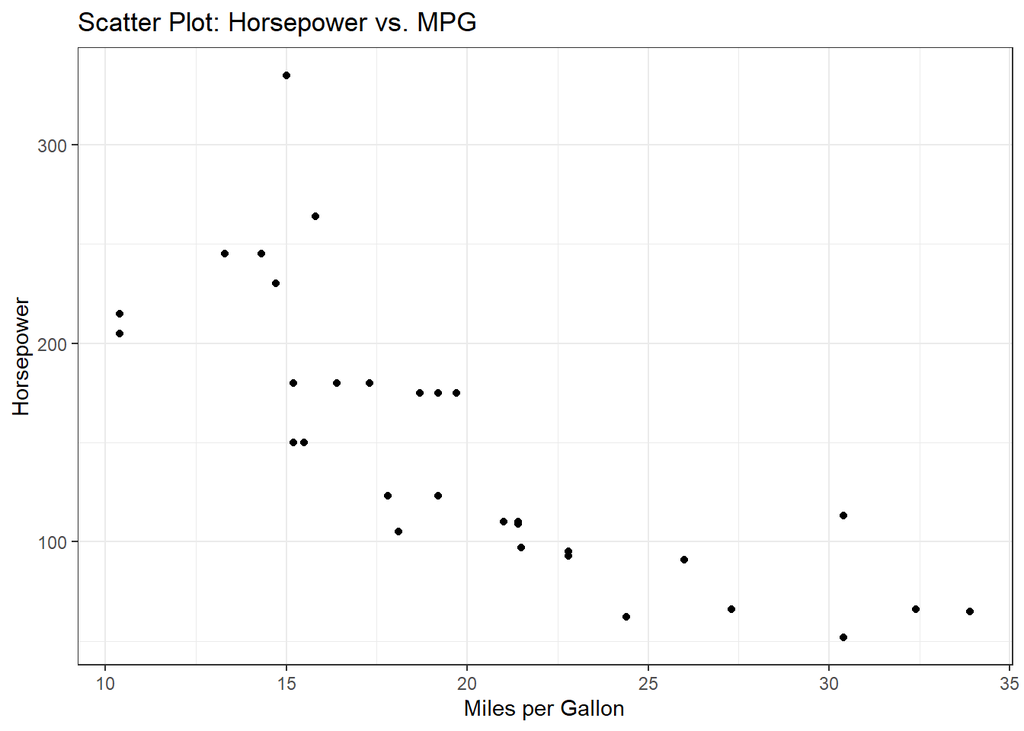

```r
# Scatter plot
ggplot(mtcars, aes(x = mpg, y = hp)) +
  geom_point() +
  labs(x = "Miles per Gallon", y = "Horsepower") +
  ggtitle("Scatter Plot: Horsepower vs. MPG") +
  theme_bw()
```

Interpretation

The scatter plot shows the relationship between horsepower and miles per gallon for different car models. We can observe that as mpg increases, horsepower tends to decrease.

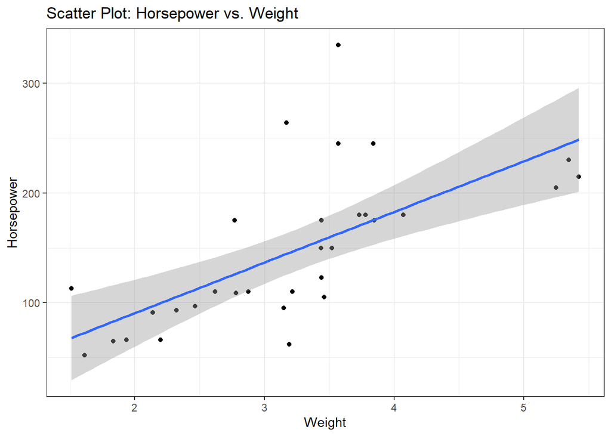

```r
# Scatter plot
ggplot(mtcars, aes(x = wt, y = hp)) +
  geom_point() +
  geom_smooth(method = "lm") + # add a line to show trend
  labs(x = "Weight", y = "Horsepower") +
  ggtitle("Scatter Plot: Horsepower vs. Weight") +
  theme_bw()
```

Interpretation

The scatter plot shows the relationship between car weight and horsepower, along with a regression line. We can observe the general trend that as weight increases, horsepower also tends to increase.

### Bar Plot with Grouping

A bar plot with grouping allows comparison of a numeric variable across different categories. Let’s create a grouped bar plot to compare average miles per gallon for different numbers of cylinders and gears.

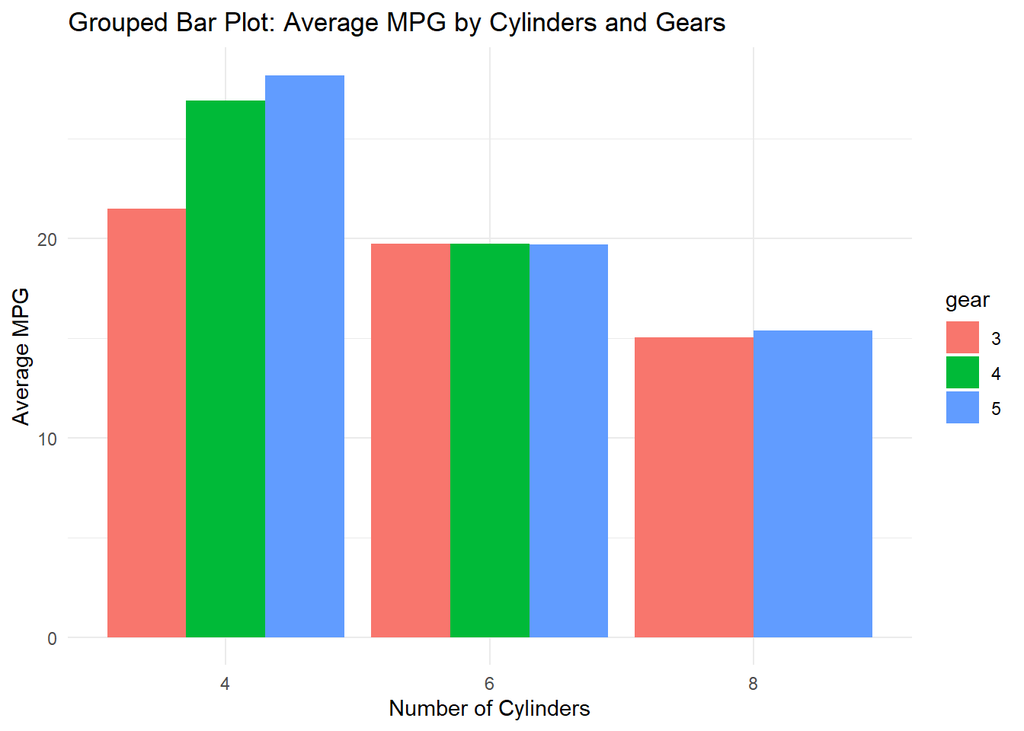

```r
# Grouped bar plot
mtcars_grouped =
  aggregate(mpg ~ cyl + gear, data = mtcars, FUN = mean) %>%
  mutate(
    gear = as.factor(gear),
    cyl = as.factor(cyl)
  )

ggplot(mtcars_grouped, aes(x = cyl, y = mpg, fill = gear)) +
  geom_bar(stat = "identity", position = "dodge") +
  labs(x = "Number of Cylinders", y = "Average MPG") +
  ggtitle("Grouped Bar Plot: Average MPG by Cylinders and Gears") +
  theme_minimal()
```

Interpretation

The grouped bar plot compares the average miles per gallon for different numbers of cylinders and gears. We can observe the variations in MPG values based on both cylinder count and gear type.

## Bar Plot

A bar plot represents the frequency or count of categorical variables. Let’s create a bar plot of the number of cars based on their number of cylinders.

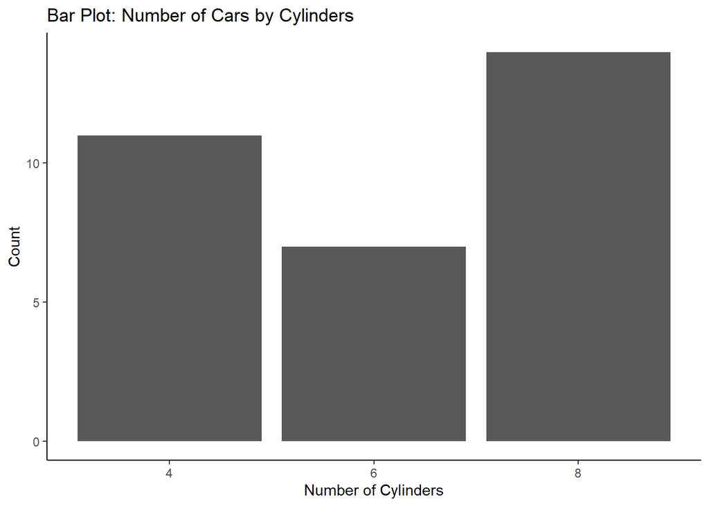

```r
# Bar plot
ggplot(mtcars, aes(x = factor(cyl))) +
  geom_bar() +
  labs(x = "Number of Cylinders", y = "Count") +
  ggtitle("Bar Plot: Number of Cars by Cylinders") +
  theme_classic()
```

Interpretation

The bar plot illustrates the count of cars based on the number of cylinders. We can see that the dataset contains a higher number of cars with 4 and 8 cylinders.

## Histogram

A histogram displays the distribution of a numeric variable. Let’s plot the distribution of car weights using a histogram.

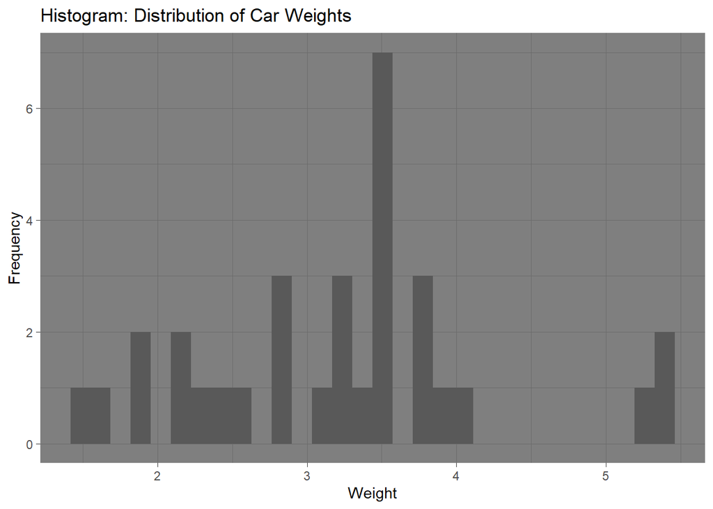

```r
# Histogram
ggplot(mtcars, aes(x = wt)) +
  geom_histogram() +
  labs(x = "Weight", y = "Frequency") +
  ggtitle("Histogram: Distribution of Car Weights") +
  theme_dark()
```

Interpretation

The histogram represents the distribution of car weights. We observe that the majority of car weights fall between 2.5 and 4.5 units.

## Box Plot

A box plot provides a summary of the distribution of a numeric variable. Let’s create a box plot to visualize the distribution of car miles per gallon based on the number of gears.

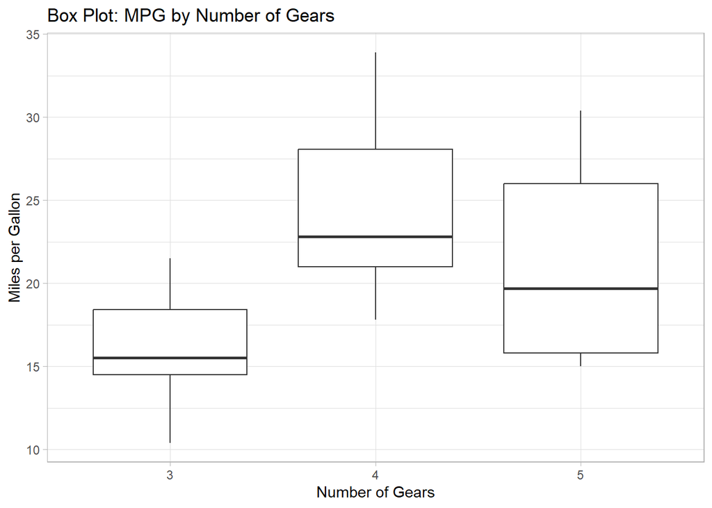

```r
# Box plot
ggplot(mtcars, aes(x = factor(gear), y = mpg)) +
  geom_boxplot() +
  labs(x = "Number of Gears", y = "Miles per Gallon") +
  ggtitle("Box Plot: MPG by Number of Gears") +
  theme_light()
```

Interpretation

The box plot displays the distribution of miles per gallon based on the number of gears. We can see the median, quartiles, and any outliers for each gear type.

## Line Plot

A line plot illustrates the trend or pattern of a numeric variable over a continuous variable. Let’s plot the car miles per gallon across various car models.

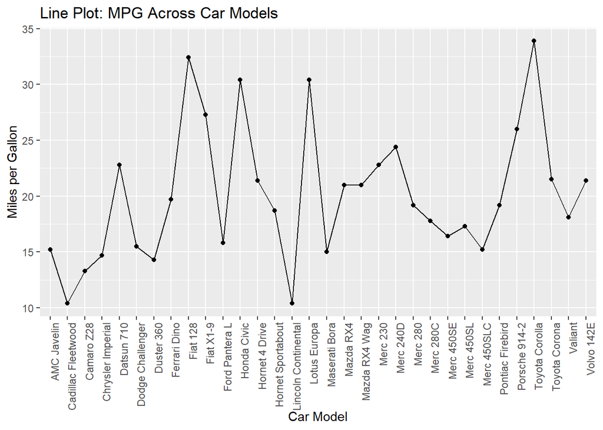

```r
# Line plot
ggplot(mtcars, aes(x = rownames(mtcars), y = mpg, group = 1)) +
  geom_line() +
   geom_point() +
  labs(x = "Car Model", y = "Miles per Gallon") +
  ggtitle("Line Plot: MPG Across Car Models") +
  theme_gray() +
  theme(axis.text.x = element_text(angle = 90, hjust = 1))
```

Interpretation

The line plot shows the trend of miles per gallon across different car models. We can observe variations in MPG values among the car models.

## Violin Plot

A violin plot displays the distribution of a numeric variable, providing insights into its density. Let’s create a violin plot for car miles per gallon based on the number of cylinders.

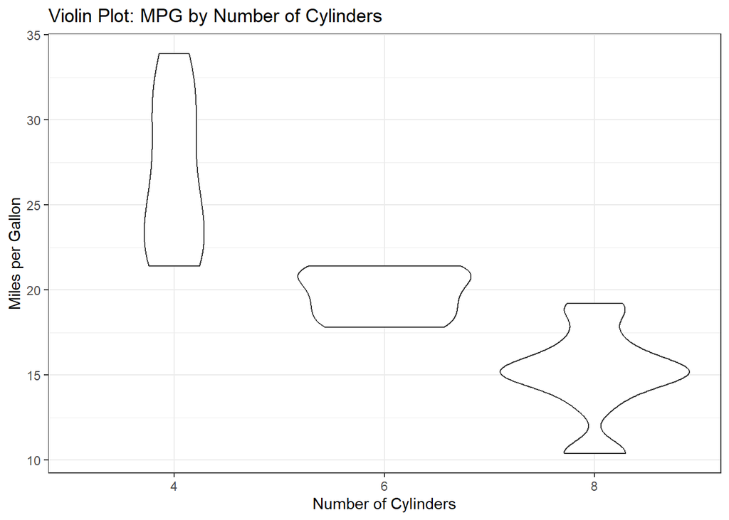

```r
# Violin plot
ggplot(mtcars, aes(x = factor(cyl), y = mpg)) +
  geom_violin() +
  labs(x = "Number of Cylinders", y = "Miles per Gallon") +
  ggtitle("Violin Plot: MPG by Number of Cylinders") +
  theme_bw()
```

Interpretation

The violin plot presents the density distribution of miles per gallon for different numbers of cylinders. We can observe the spread and concentration of MPG values for each cylinder count.

## Heatmap

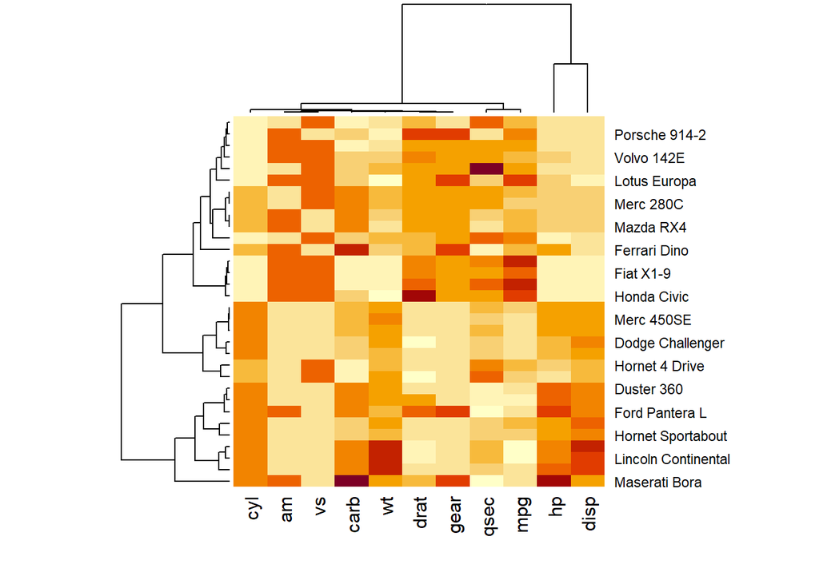

```r
# scaling the data
data = as.matrix(mtcars)
# Heatmap
heatmap(data, scale="column")
```

CONGRATULATIONS, YOU HAVE MADE IT TO THE END OF THE LESSON. PROCEED TO THE ASSIGNMENT.